# Premier League Football Exploration

This report explores a dataset containing 25+ variables for 5,170 matches. It comes from http://www.football-data.co.uk/englandm.php

some variables have used the abbreviation, whose description are shown below:

1. HomeTeam = Home Team
2. AwayTeam = Away Team
3. FTHG = Full-Time Home Team Goals
4. FTAG = Full-Time Away Team Goals
5. FTR = Full-Time Result (H=Home Win, D=Draw, A=Away Win)
6. Referee = Match Referee
7. HS = Home Team Shots
8. AS = Away Team Shots
9. HST = Home Team Shots on Target
10. AST = Away Team Shots on Target
11. HF = Home Team Fouls Committed
12. AF = Away Team Fouls Committed
13. HO = Home Team Offsides
14. AO = Away Team Offsides
15. HY = Home Team Yellow Cards
16. AY = Away Team Yellow Cards
17. HR = Home Team Red Cards
18. AR = Away Team Red Cards

# Main question

What factor can influence the result of a match in Premier League?

# Univariate Plots Section

## Overview

```
##        X             Year            HomeTeam         AwayTeam
##  Min.   :   1   Min.   :2004   Arsenal   : 259   Chelsea  : 259
##  1st Qu.:1293   1st Qu.:2007   Man United: 259   Everton  : 259
##  Median :2586   Median :2010   Chelsea   : 258   Liverpool: 259
##  Mean   :2586   Mean   :2010   Everton   : 258   Man City : 259
##  3rd Qu.:3878   3rd Qu.:2014   Liverpool : 258   Tottenham: 259
##  Max.   :5170   Max.   :2017   Man City  : 258   Arsenal  : 258
##                                (Other)   :3620   (Other)  :3617
##       FTHG           FTAG           FTG         FTR
##  Min.   :0.00   Min.   :0.00   Min.   : 0.000   A:1451
##  1st Qu.:1.00   1st Qu.:0.00   1st Qu.: 2.000   D:1331
##  Median :1.00   Median :1.00   Median : 2.000   H:2388
##  Mean   :1.53   Mean   :1.13   Mean   : 2.531
##  3rd Qu.:2.00   3rd Qu.:2.00   3rd Qu.: 3.000
##  Max.   :9.00   Max.   :6.00   Max.   :10.000
##
##           Referee           HS              AS             HST
##  M Dean       : 363   Min.   : 1.00   Min.   : 0.00   Min.   : 0.000
##  M Atkinson   : 307   1st Qu.:10.00   1st Qu.: 7.00   1st Qu.: 4.000
##  H Webb       : 296   Median :13.00   Median :10.00   Median : 6.000
##  M Clattenburg: 288   Mean   :13.66   Mean   :10.69   Mean   : 6.638
##  P Dowd       : 287   3rd Qu.:17.00   3rd Qu.:13.00   3rd Qu.: 9.000
##  C Foy        : 250   Max.   :43.00   Max.   :30.00   Max.   :24.000
##  (Other)      :3379
##       AST               HC               AC               HF
##  Min.   : 0.000   Min.   : 0.000   Min.   : 0.000   Min.   : 1.0
##  1st Qu.: 3.000   1st Qu.: 4.000   1st Qu.: 3.000   1st Qu.: 9.0
##  Median : 5.000   Median : 6.000   Median : 4.000   Median :11.0
##  Mean   : 5.109   Mean   : 6.147   Mean   : 4.825   Mean   :11.4
##  3rd Qu.: 7.000   3rd Qu.: 8.000   3rd Qu.: 6.000   3rd Qu.:14.0
##  Max.   :20.000   Max.   :20.000   Max.   :19.000   Max.   :33.0
##
##        AF           HY              AY             HR
##  Min.   : 1   Min.   :0.000   Min.   :0.00   Min.   :0.0000
##  1st Qu.: 9   1st Qu.:0.000   1st Qu.:1.00   1st Qu.:0.0000
##  Median :12   Median :1.000   Median :2.00   Median :0.0000
##  Mean   :12   Mean   :1.388   Mean   :1.78   Mean   :0.0646
##  3rd Qu.:14   3rd Qu.:2.000   3rd Qu.:3.00   3rd Qu.:0.0000
##  Max.   :28   Max.   :7.000   Max.   :9.00   Max.   :3.0000
##
##        AR              Season
##  Min.   :0.00000   Min.   :2003
##  1st Qu.:0.00000   1st Qu.:2006
##  Median :0.00000   Median :2009
##  Mean   :0.09497   Mean   :2009
##  3rd Qu.:0.00000   3rd Qu.:2013
##  Max.   :2.00000   Max.   :2016
##
```

## winning times

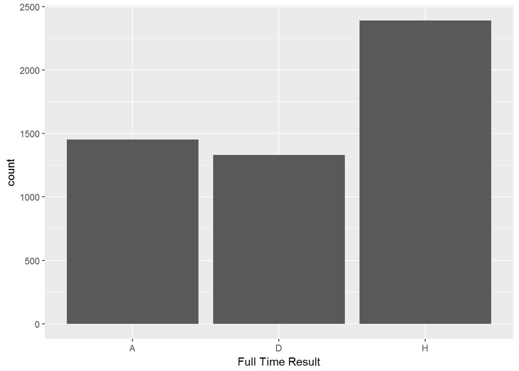

From this plot above, it is clear that Home Team has won more matches from 2003-2016 Premier League.

## Full time goals

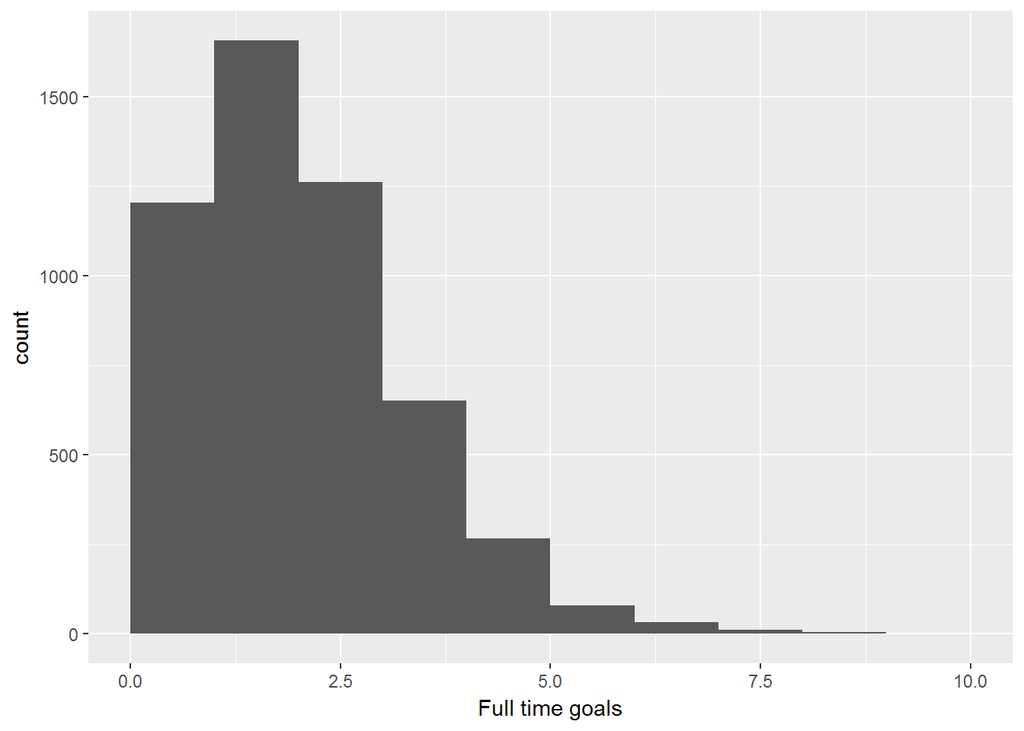

## Full time shots

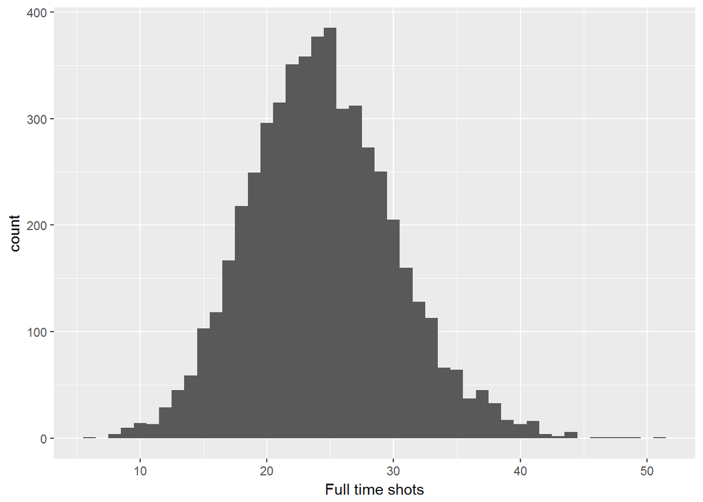

From above plot, the full time shot seems to be a normal distribution, most full time shots was bewteen 20 and 30.

## Full time shot on target

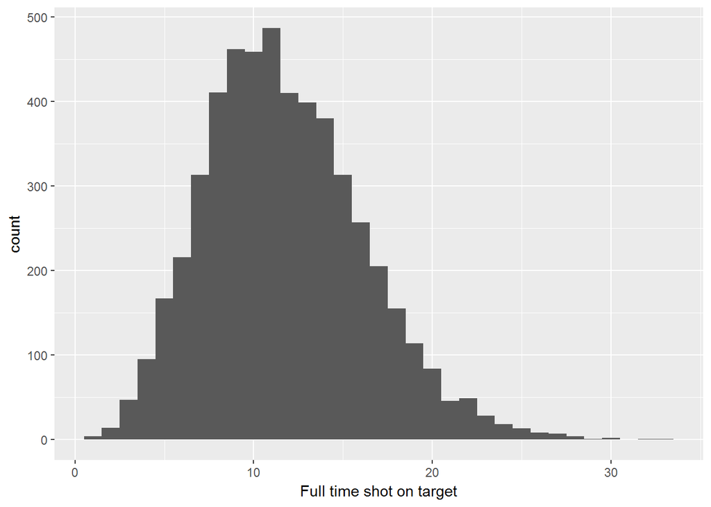

From above plot, the full time shot on target also seems to be a normal distribution. Most shot on target was around 10.

## Cards

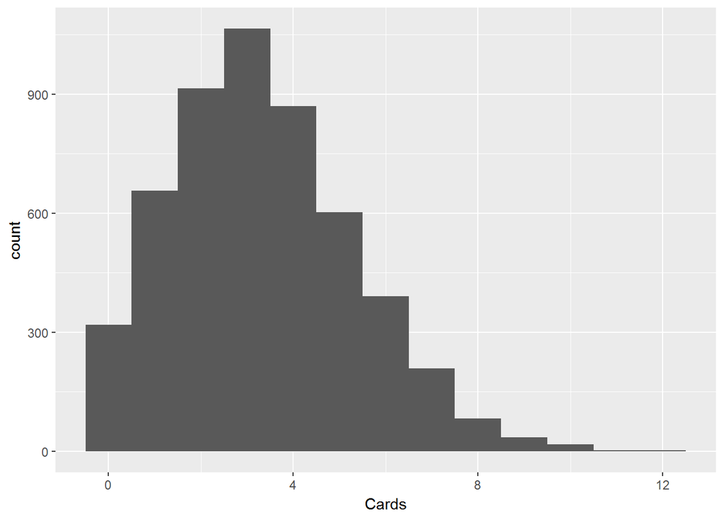

Above plot is the histogram of cards, In most matches, the number of cards was less than 4. And the max can be up to 12.

## Full time corners

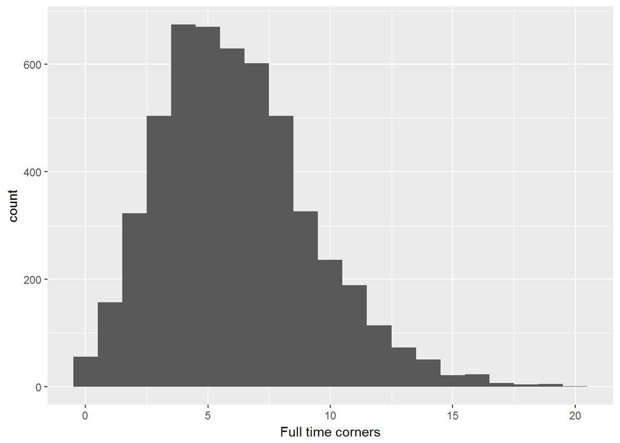

Most matches had around five corners full time. And there existed that full time match had zero corner. It was really rare. And max number can up to 20.

# Bivariate Analysis and Multivariate Plots Section

> Attention: To make the analysis more like a report and interesting, I will analysis several factors in football matches, so bivariate and multivariate plots are mixed, because they are connected and easy to understand together.

## Home VS Away?

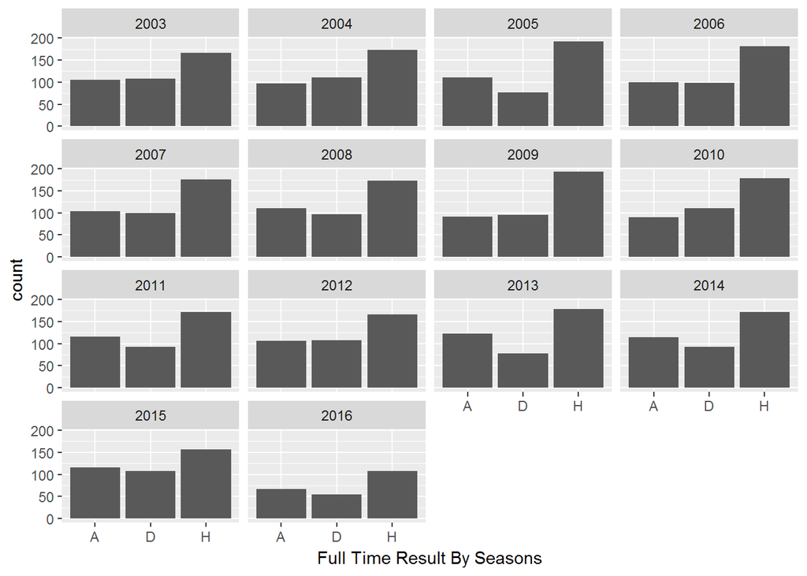

### Full time goals

Home team

```
##    Min. 1st Qu.  Median    Mean 3rd Qu.    Max.
##    0.00    1.00    1.00    1.53    2.00    9.00
```

Away team

```
##    Min. 1st Qu.  Median    Mean 3rd Qu.    Max.
##    0.00    0.00    1.00    1.13    2.00    6.00
```

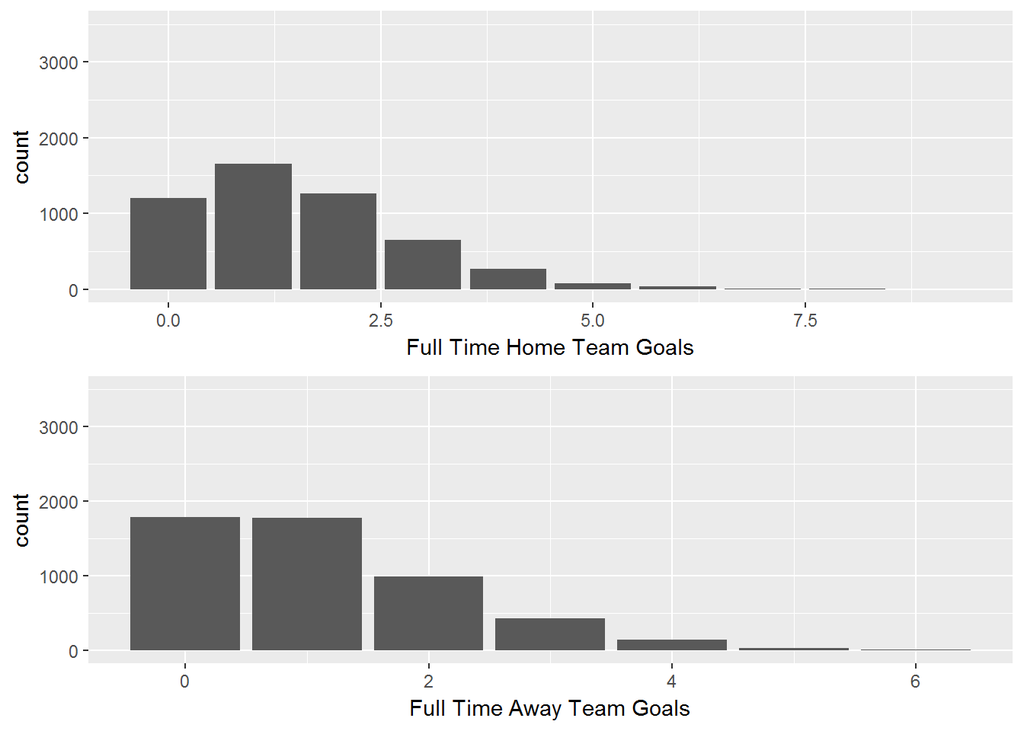

Comparing the full-time goals, mean and max of Home Team is higher than that of Away team, so it means, home team won more games because of it had more goals than away team on the average. While, this seems a little meaningless because the goal number decide the game results.

However, Home teams seem to have advantages because they are more familiar with the pitch they play on. They spend a lot of time training tactics and shooting on their own pitch and they know the environment better than the away teams. I guess the home teams shoot more than away team on average.

### Shots

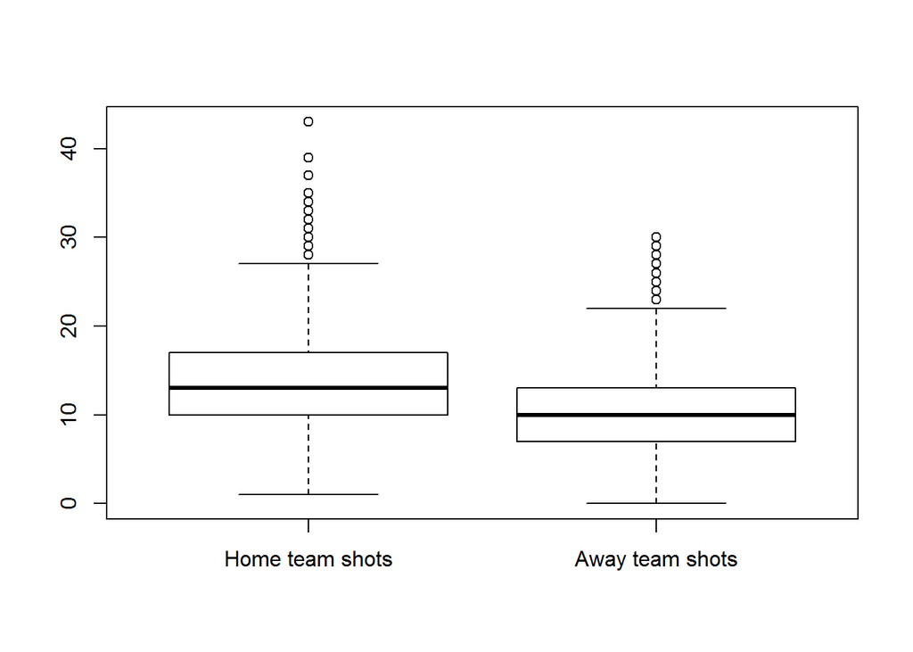

### Shots on Target

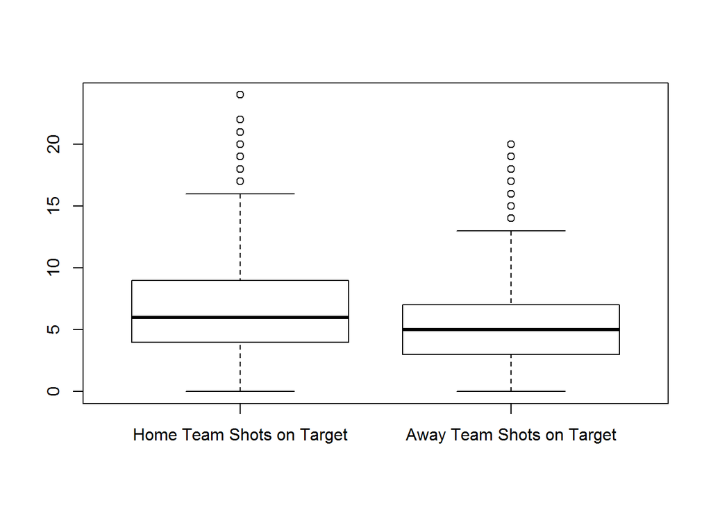

It is clear that my guess is right, from two box plots above, home teams attempted to shot more than away teams and the shot on target is higher than away team, it seems home teams know where the net is.

### Corner

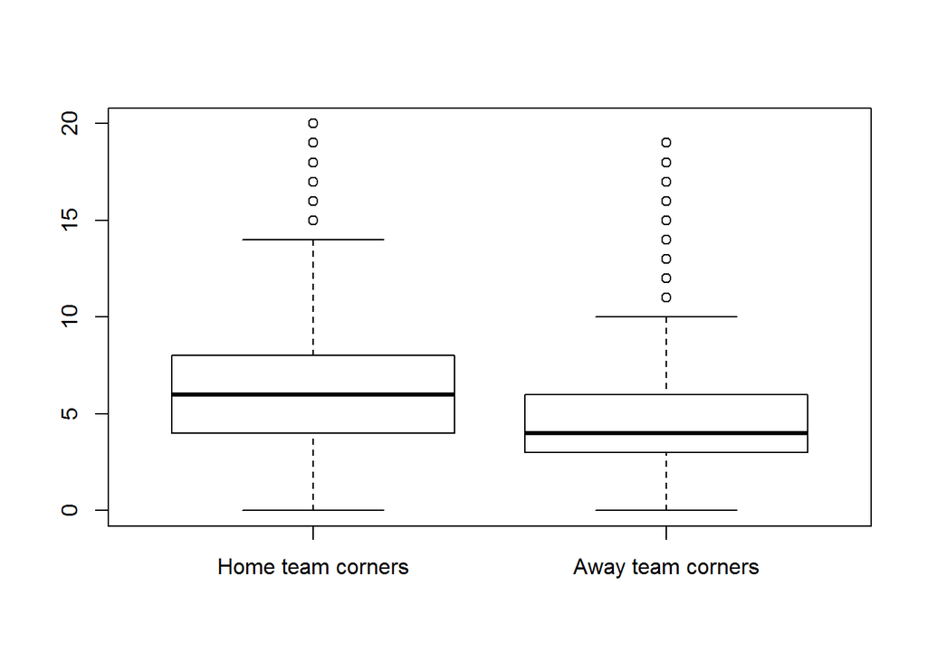

In the aspect of the corner, it is obvious that home team have more advantages on corners, more corners mean more opportunities to goal, it increased the possibility of home team win.

## The exploration on teams

Next, I want to check how different teams perform from several aspects, such as performances as Home and Away, shot times and foul times.

### Plot by Home team

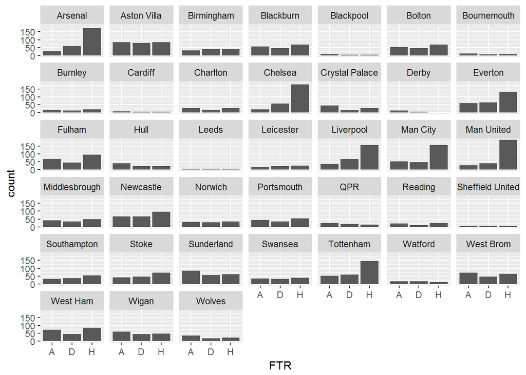

### Plot by Away team

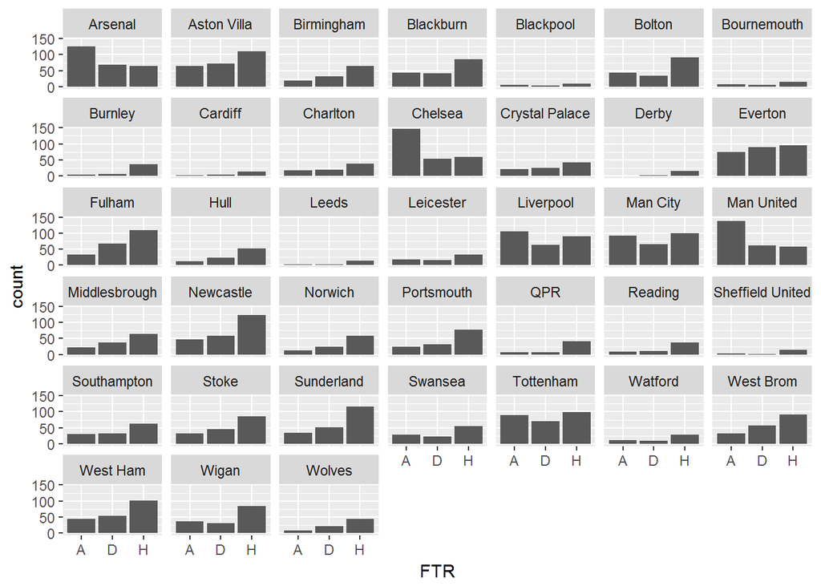

```
## # A tibble: 6 × 4
##         team   win     n  win_rate
##       <fctr> <dbl> <int>     <dbl>
## 1 Man United   190   259 0.7335907
## 2    Chelsea   179   258 0.6937984
## 3    Arsenal   173   259 0.6679537
## 4   Man City   157   258 0.6085271
## 5  Liverpool   156   258 0.6046512
## 6  Tottenham   147   258 0.5697674
```

```
## # A tibble: 6 × 4
##        team   win     n   win_rate
##      <fctr> <dbl> <int>      <dbl>
## 1     Derby     1    19 0.05263158
## 2 Blackpool     5    19 0.26315789
## 3   Cardiff     5    19 0.26315789
## 4     Leeds     5    19 0.26315789
## 5       QPR    15    57 0.26315789
## 6   Watford    13    49 0.26530612
```

```
## # A tibble: 6 × 4
##         team   win     n  win_rate
##       <fctr> <dbl> <int>     <dbl>
## 1    Chelsea   146   259 0.5637066
## 2 Man United   138   258 0.5348837
## 3    Arsenal   125   258 0.4844961
## 4  Liverpool   106   259 0.4092664
## 5   Man City    93   259 0.3590734
## 6  Tottenham    90   259 0.3474903
```

```
## # A tibble: 6 × 4
##      team   win     n   win_rate
##    <fctr> <dbl> <int>      <dbl>
## 1   Derby     0    19 0.00000000
## 2 Burnley     4    48 0.08333333
## 3 Cardiff     2    19 0.10526316
## 4  Wolves     9    76 0.11842105
## 5     QPR     7    57 0.12280702
## 6 Norwich    12    95 0.12631579
```

## Summary of win rate rate by teams

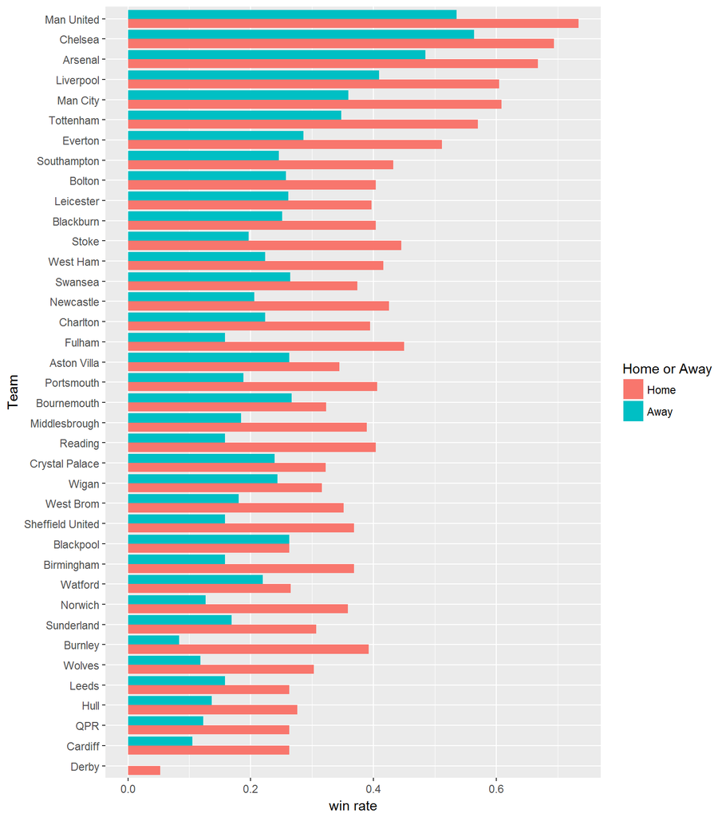

From the summary plot, We can see Man United, Chelsa, Arsenal, Liverpool and Man city are teams that performed both well whether they are home teams or away teams. In addition to the above teams, some are also difficult to beat at home, such as Stoke and Fulham.

## Fouls and win rate

In our impression, if a team is very fierce on the pitch, it is likely to win the game; The opponents are afraid of them. So I want to verify this views, whether the more fierce a team is, the higher possibility to win it has. I will compare the fierce rate with win rate.

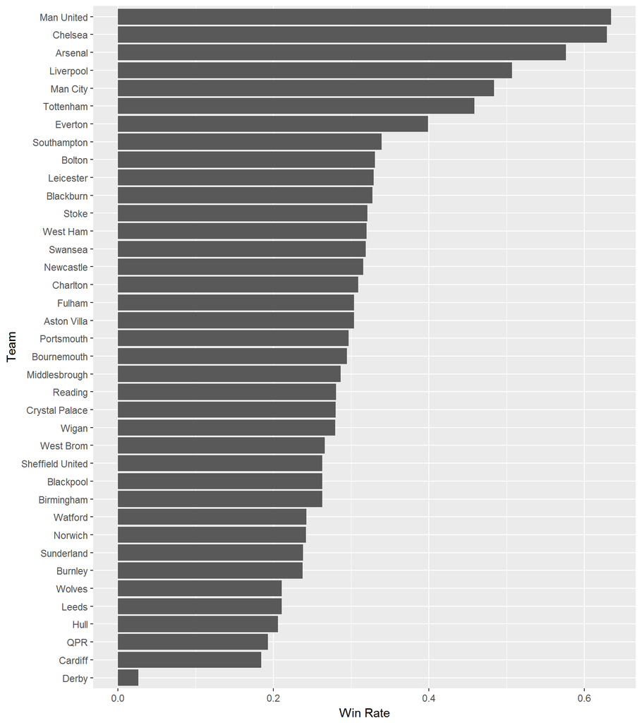

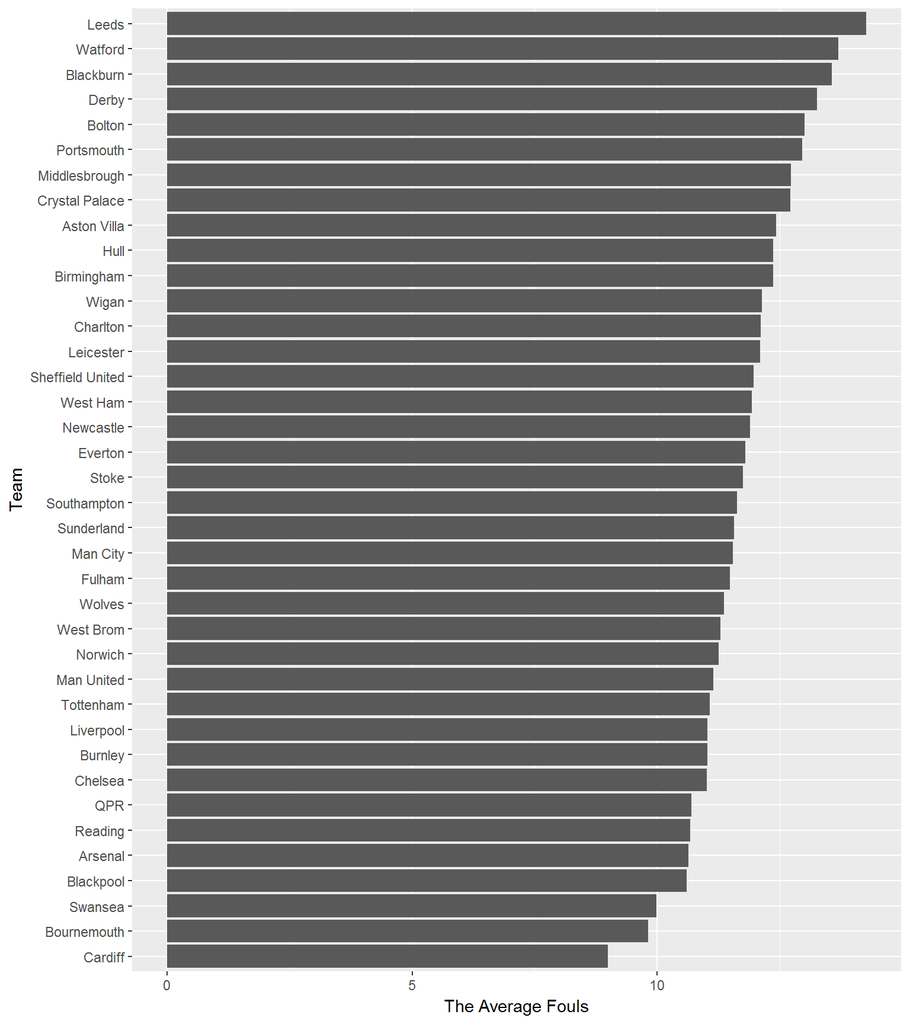

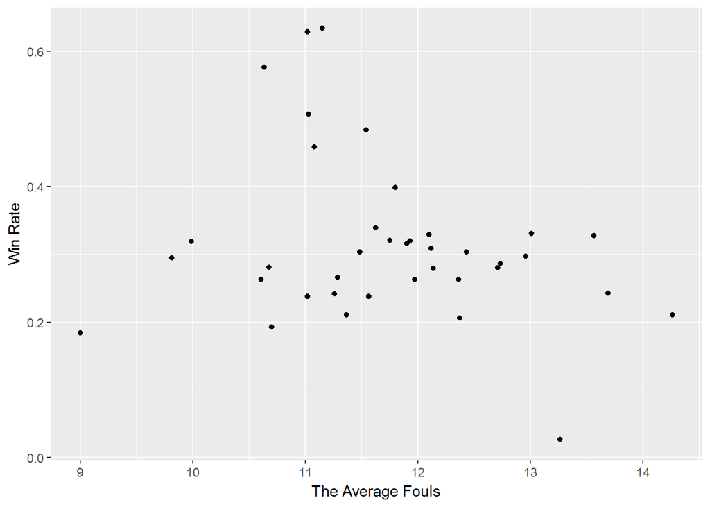

While it seems foul is uncorrelated with win rate. We can see the highest win rate team has a low fouls. The win rate of the team who has the highest foul is much lower. It can be explained by the fact that sometimes better team didn’t need to make fouls to win the game. As a result, a fierce team is likely to be a team that feel more pressure on matches, so it seems fierce to try to win the game. While the team has great advantage may be more gentle on the pitches.

## Shot on target and win rate

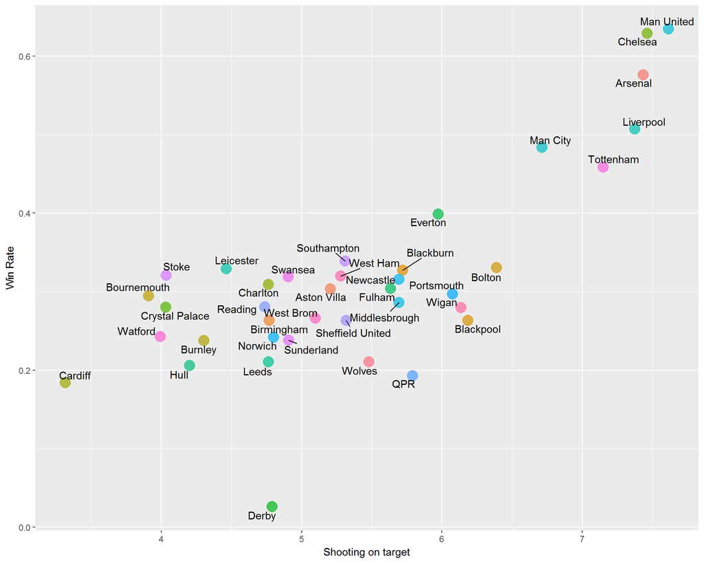

## Win rate and Referre

Referee is another important factor in the football game. Different referee has a different style, it influenced the game.

## Referee influence on th results

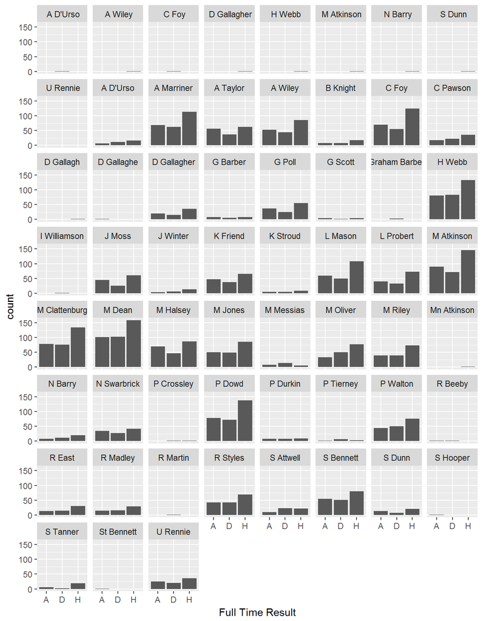

Home team to away wins

```
##    Min. 1st Qu.  Median    Mean 3rd Qu.    Max.
##   0.000   1.327   1.643   1.621   1.887   4.333
```

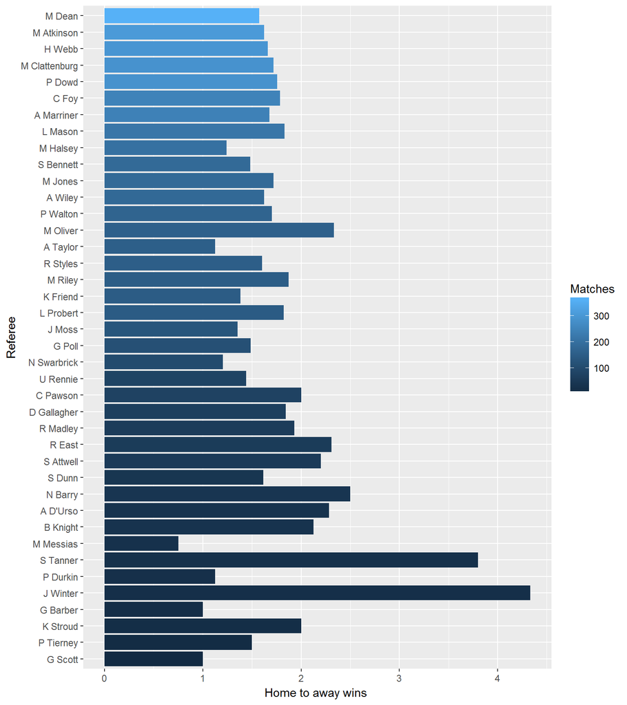

Then, I try to compare all these referees in the same plot. I use the home team to away wins as the x-axis, and the number of away team win as x-axis under the each referee.In this plot, I can see home team won more than away team under any referee almost(all the number is larger than 1). But I can still observe home team may have a high probability of victory when their referee is, for example, Oliver and Reliy. If the referee is Halsey, the home team may be careful, because the ration of Halsey and Taylor is much lower than the mean.

### Referee and Card

I also want to explore the relation between referee and cards. Some referees are famous for strict and often give yellow cards and red cards.

The summary of matches each referee officated

```
##    Min. 1st Qu.  Median    Mean 3rd Qu.    Max.
##    1.00    1.50   39.00   87.63  155.00  363.00
```

Because the median number is 39, so I only choose the referees who officiated more the 39 matches.

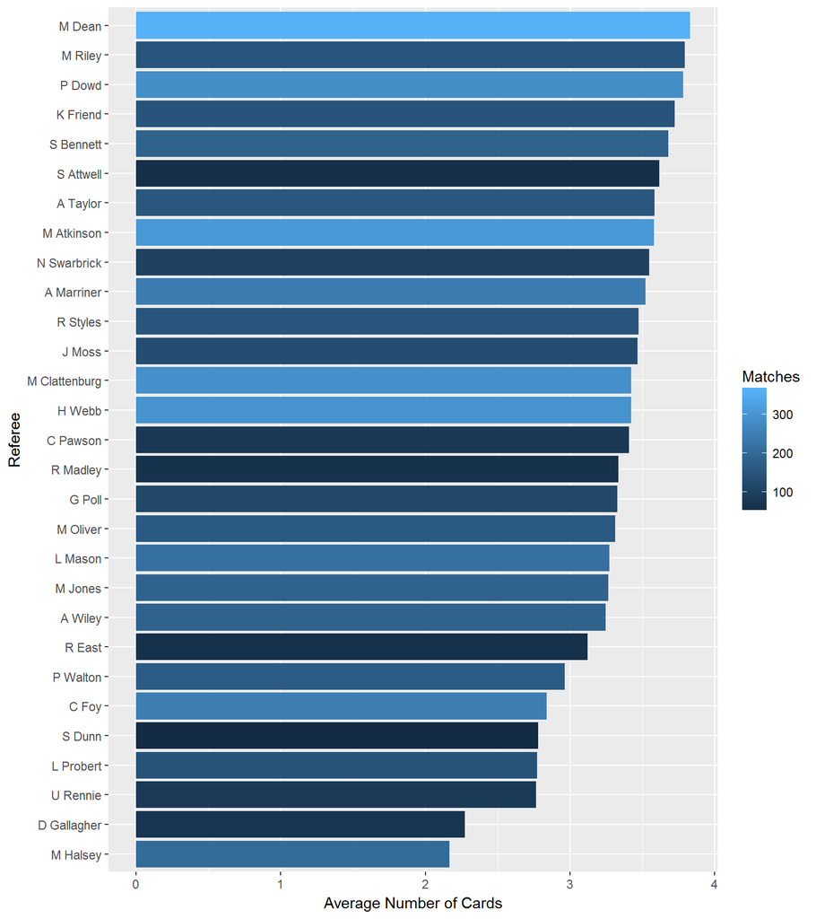

## Full Time Goals with the year

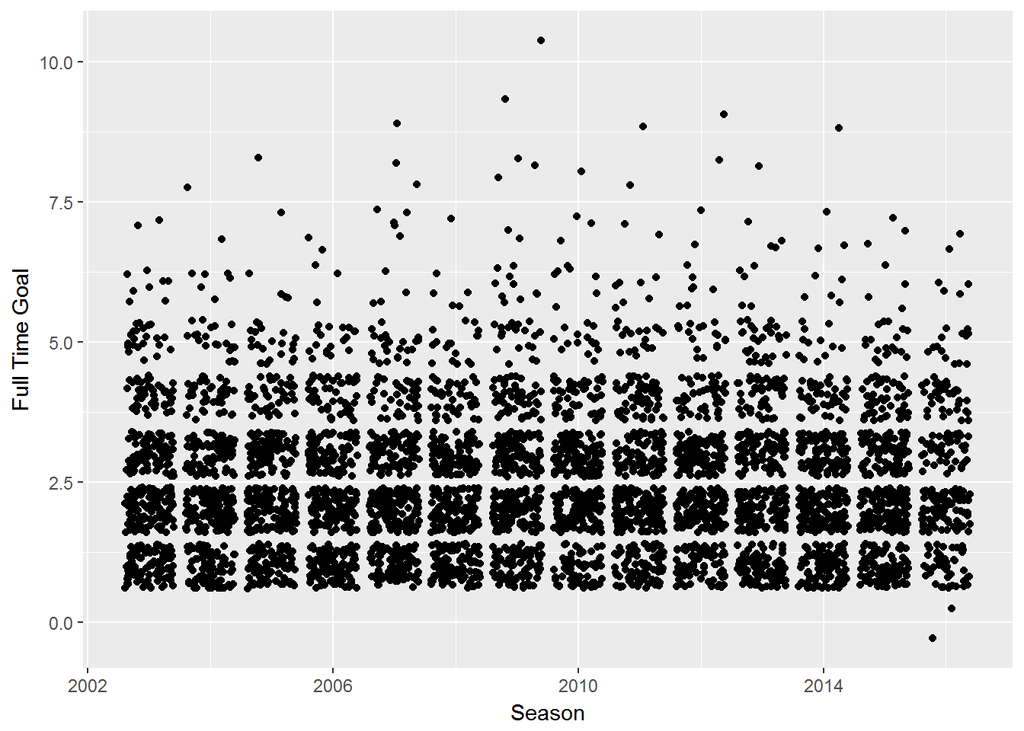

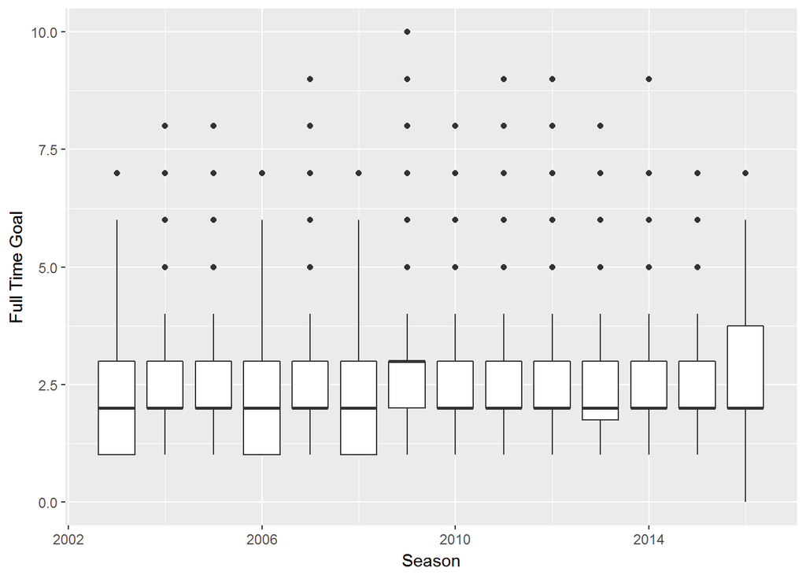

This plot is interesting. If you don’t know Premier League before, you can still see there are clear intervals between different seasons. In fact, these are holidays for the Premier League players. It usually lasts two months, from June and July. Besides, we can also find the highest goals in a match happens in season 2009.

The below plots shows the average number of goals, shots, shots on target, cards and corner by different numbers.

## Goals by season

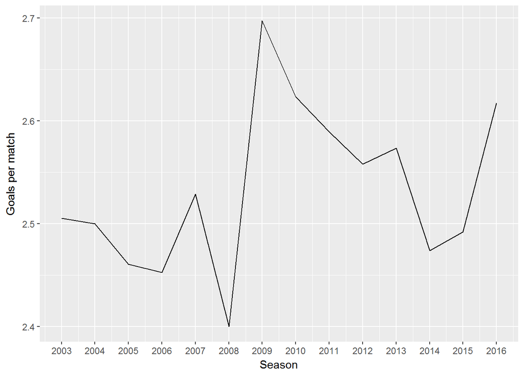

From 2003- 2016 seasons, 2009 was the year had highest goals per match. It was a highly ornamental season. Later, the number decreased. But we can see there is a increasing trend in 2016 season. While, 2016 season is still on, so let’s wait and see what happens.

## Shots by season

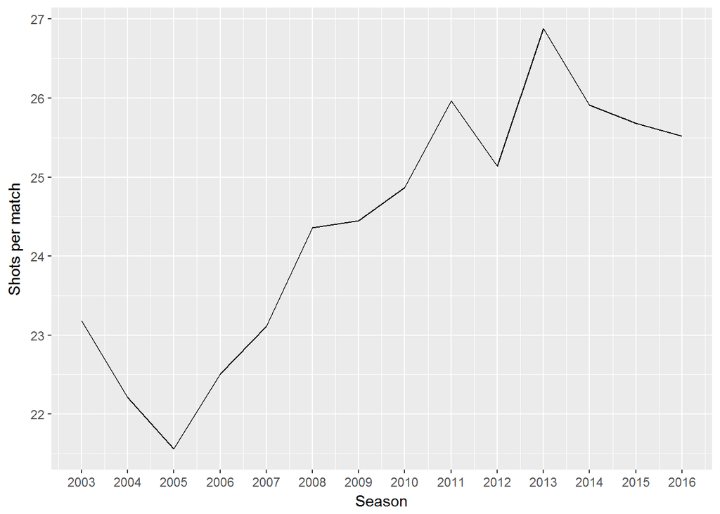

The average shots appears rising trend since 2005. It means players tried to shot more than before, to be honest, this trend shows that the Premier League is more Worth seeing.

## Shots on target by season

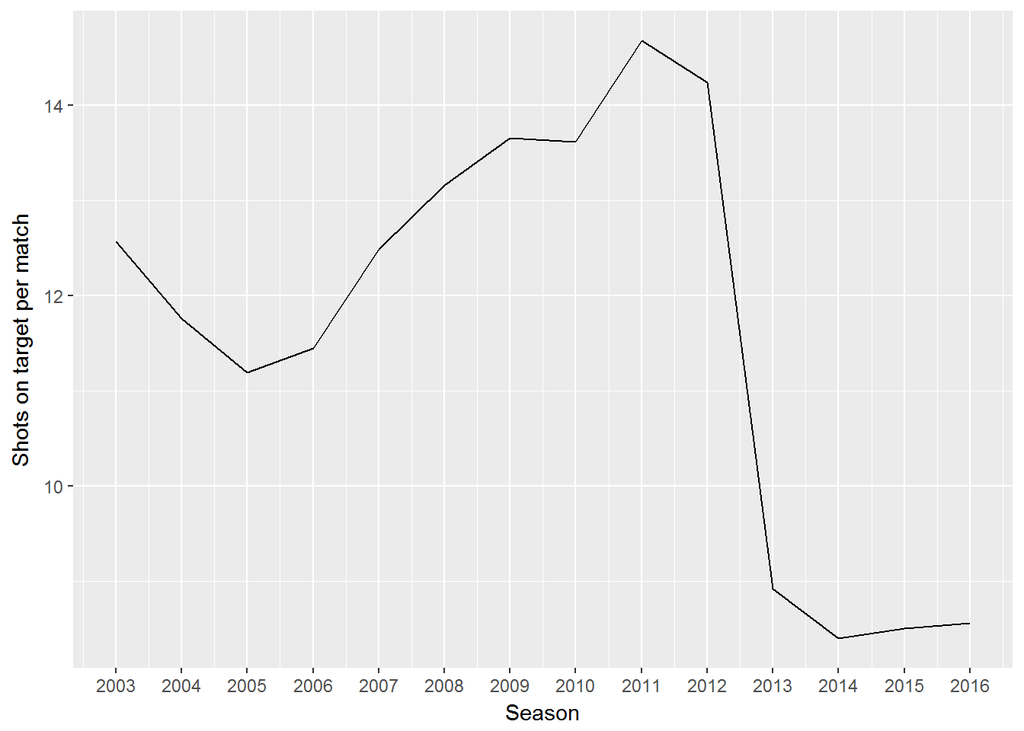

There is a obvious decrease of shots on target from 2012 to 2014, and it perhaps will keep at a low level for in the fture. According to the common sense, the shots on target should increase due to the increase of shots. However, the fact is reverse.

## Cards by season

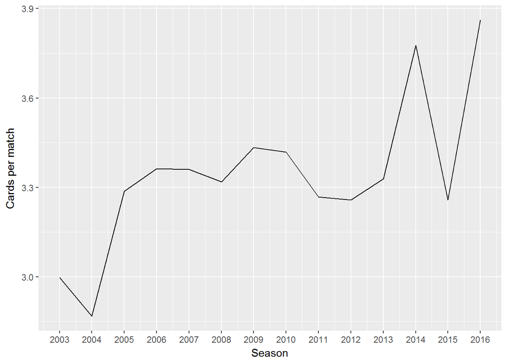

The cards number is increasing with fluctuations. It shows that the premier league is more and more fierce and worth seeing!!!

## Corner by season

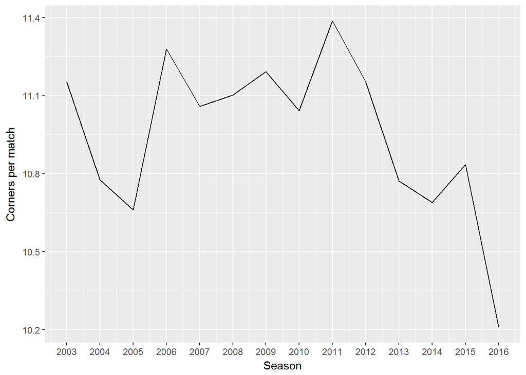

While, the corner number reduces from 2003 to 2016.

## Home team Win rate by Season

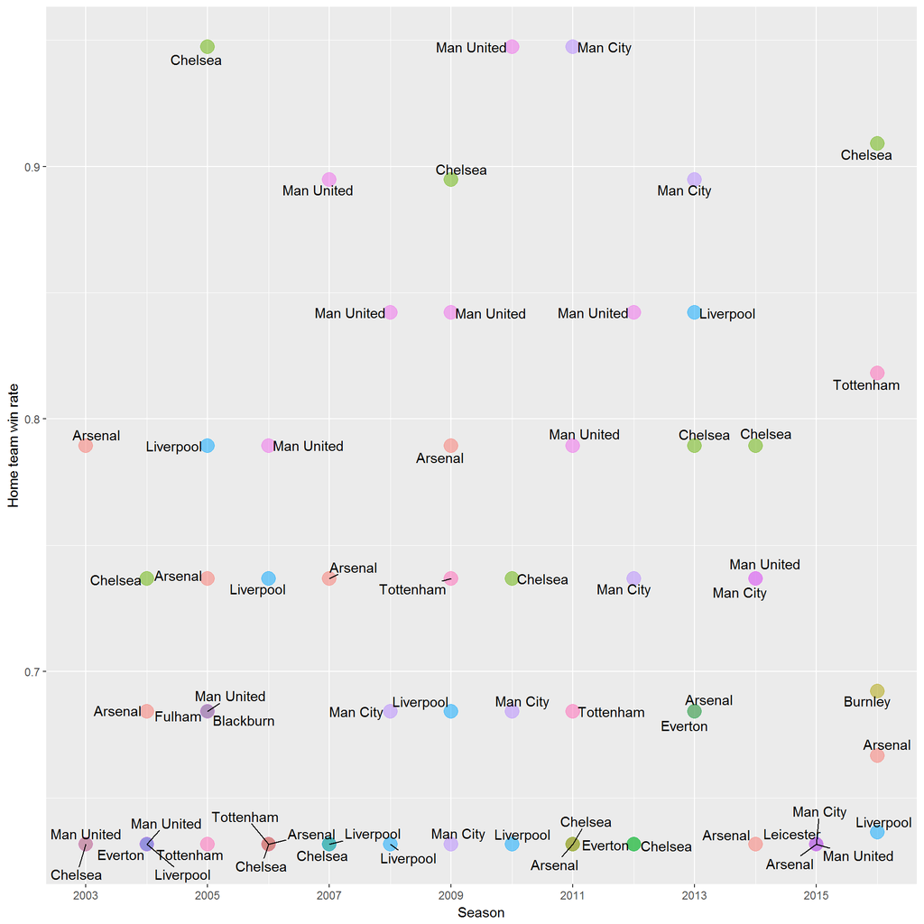

## Away team win rate by season

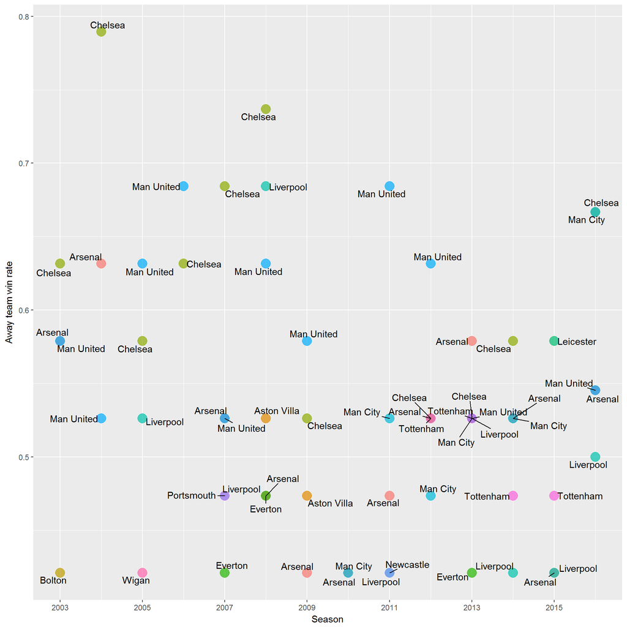